# BPA calculation of BMD and overall uncertainty

## Evaluate influence on the 5th percentile of lowest BMD of clusters using leave-one-out (when the ALI has been removed)

```r
clid_remove = 1
clusters_all <- c('all',clusters[-clid_remove])
sa_c2 <- do.call('rbind',lapply(1:length(clusters_all),function(clid){
objective1 <- function(d){(get_p(d,loo=c(clusters[clid_remove],clusters_all[clid]))$lower-0.05)^2}

objective2 <- function(d){(get_p(d,loo=c(clusters[clid_remove],clusters_all[clid]))$upper-0.05)^2}

df_opt <- data.frame(lower = optimize(objective1,interval = c(-10,10))$minimum,
upper = optimize(objective2,interval = c(-10,10))$minimum,cdf = 0.05,mind = min(df_env_all$dose),cluster = clusters_all[clid])
}))
```

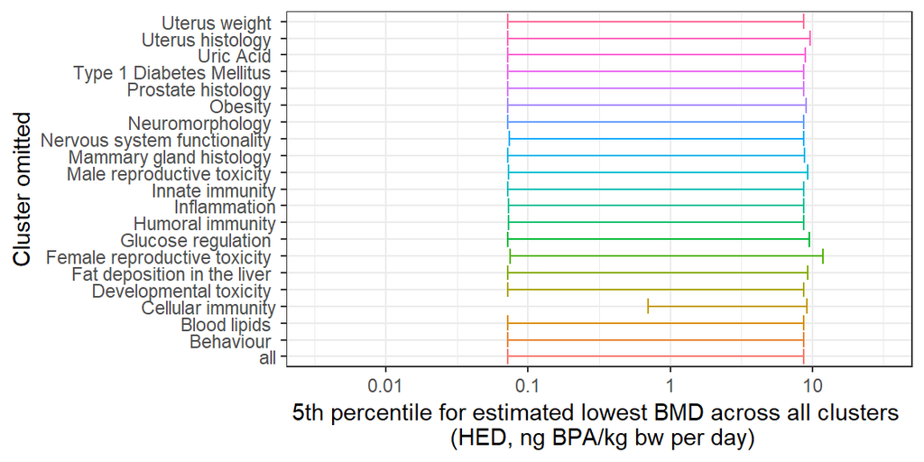

```r
ggplot(sa_c2,aes(y=cluster,x=lower,fill=cluster))+
# geom_point() +
  geom_errorbarh(aes(xmin = lower,xmax = upper,col=cluster))+
 # xlim(-2,-1) +
#  facet_wrap(~iter) +
  theme_bw()+
  ylab("Cluster omitted") +
  theme(legend.position = "none") +
  scale_x_continuous(name="5th percentile for estimated lowest BMD across all clusters \n (HED, ng BPA/kg bw per day)", breaks=breaks, labels=10^breaks,limits = limits2)
```

```r
  #ggtitle("Sensitivity analysis without Allergic lung inflammation", subtitle="Leave-one-out")
```

```r
clid_remove = 1
clusters_all <- c('all',clusters[-clid_remove])
sa_c2_50 <- do.call('rbind',lapply(1:length(clusters_all),function(clid){
objective1 <- function(d){(get_p(d,loo=c(clusters[clid_remove],clusters_all[clid]))$lower-0.5)^2}

objective2 <- function(d){(get_p(d,loo=c(clusters[clid_remove],clusters_all[clid]))$upper-0.5)^2}

df_opt <- data.frame(lower = optimize(objective1,interval = c(-10,10))$minimum,
upper = optimize(objective2,interval = c(-10,10))$minimum,cdf = 0.5,mind = min(df_env_all$dose),cluster = clusters_all[clid])
}))
```

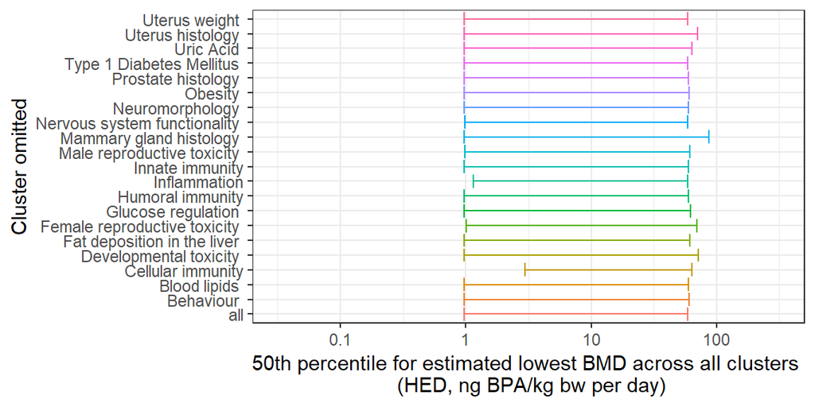

```r
ggplot(sa_c2_50,aes(y=cluster,x=lower,fill=cluster))+
# geom_point() +
  geom_errorbarh(aes(xmin = lower,xmax = upper,col=cluster))+
 # xlim(-2,-1) +
#  facet_wrap(~iter) +
  theme_bw()+
  ylab("Cluster omitted") +
  theme(legend.position = "none") +
  scale_x_continuous(name="50th percentile for estimated lowest BMD across all clusters \n (HED, ng BPA/kg bw per day)", breaks=breaks, labels=10^breaks,limits = limits2_50)
```

```r
  #ggtitle("Sensitivity analysis without Allergic lung inflammation", subtitle="Leave-one-out")
```

## Evaluate influence on the 5th percentile of lowest BMD of clusters using leave-one-out (when the CI has been removed)

```r
clid_remove = 2
clusters_all <- c('all',clusters[-clid_remove])
sa_c3 <- do.call('rbind',lapply(1:length(clusters_all),function(clid){
objective1 <- function(d){(get_p(d,loo=c(clusters[clid_remove],clusters_all[clid]))$lower-0.05)^2}

objective2 <- function(d){(get_p(d,loo=c(clusters[clid_remove],clusters_all[clid]))$upper-0.05)^2}

df_opt <- data.frame(lower = optimize(objective1,interval = c(-10,10))$minimum,
upper = optimize(objective2,interval = c(-10,10))$minimum,cdf = 0.05,mind = min(df_env_all$dose),cluster = clusters_all[clid])
}))
```

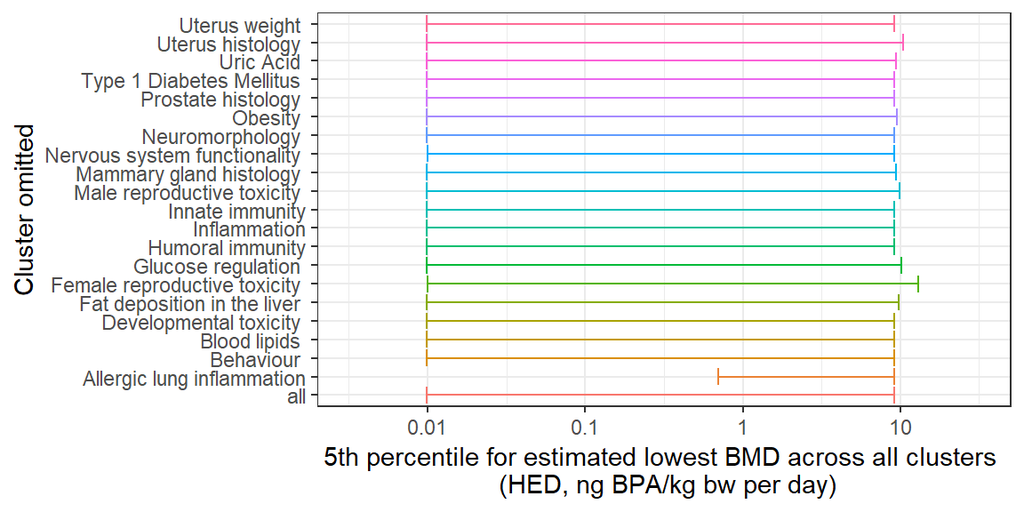

```r
ggplot(sa_c3,aes(y=cluster,x=lower,fill=cluster))+
# geom_point() +
  geom_errorbarh(aes(xmin = lower,xmax = upper,col=cluster))+
 # xlim(-2,-1) +
#  facet_wrap(~iter) +
  theme_bw()+
  ylab("Cluster omitted") +
  theme(legend.position = "none") +
  scale_x_continuous(name="5th percentile for estimated lowest BMD across all clusters \n (HED, ng BPA/kg bw per day)", breaks=breaks, labels=10^breaks,limits = limits2)
```

```r
  #ggtitle("Sensitivity analysis without Allergic lung inflammation", subtitle="Leave-one-out")
```

## Evaluate influence on the 5th percentile of lowest BMD of clusters using leave-one-out (when both ALI and CI has been removed)

```r
clid_remove = c(1,2)
clusters_all <- c('all',clusters[-clid_remove])
sa_c4 <- do.call('rbind',lapply(1:length(clusters_all),function(clid){
objective1 <- function(d){(get_p(d,loo=c(clusters[clid_remove],clusters_all[clid]))$lower-0.05)^2}

objective2 <- function(d){(get_p(d,loo=c(clusters[clid_remove],clusters_all[clid]))$upper-0.05)^2}

df_opt <- data.frame(lower = optimize(objective1,interval = c(-10,10))$minimum,
upper = optimize(objective2,interval = c(-10,10))$minimum,cdf = 0.05,mind = min(df_env_all$dose),cluster = clusters_all[clid])
}))
```

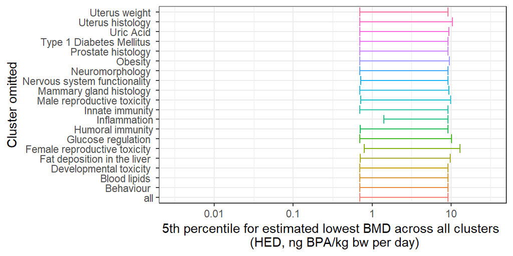

```r
ggplot(sa_c4,aes(y=cluster,x=lower,fill=cluster))+
# geom_point() +
  geom_errorbarh(aes(xmin = lower,xmax = upper,col=cluster))+
 # xlim(-2,-1) +
#  facet_wrap(~iter) +
  theme_bw()+
  ylab("Cluster omitted") +
  theme(legend.position = "none") +
  scale_x_continuous(name="5th percentile for estimated lowest BMD across all clusters \n (HED, ng BPA/kg bw per day)", breaks=breaks, labels=10^breaks,limits = limits2)
```

```r
  #ggtitle("Sensitivity analysis without Allergic lung inflammation", subtitle="Leave-one-out")
```

```r
clid_remove = c(1,2)
clusters_all <- c('all',clusters[-clid_remove])
sa_c4_50 <- do.call('rbind',lapply(1:length(clusters_all),function(clid){
objective1 <- function(d){(get_p(d,loo=c(clusters[clid_remove],clusters_all[clid]))$lower-0.5)^2}

objective2 <- function(d){(get_p(d,loo=c(clusters[clid_remove],clusters_all[clid]))$upper-0.5)^2}

df_opt <- data.frame(lower = optimize(objective1,interval = c(-10,10))$minimum,
upper = optimize(objective2,interval = c(-10,10))$minimum,cdf = 0.5,mind = min(df_env_all$dose),cluster = clusters_all[clid])
}))
```

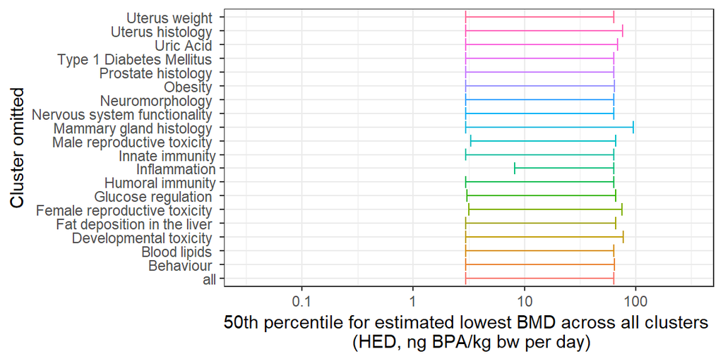

```r
ggplot(sa_c4_50,aes(y=cluster,x=lower,fill=cluster))+
# geom_point() +
  geom_errorbarh(aes(xmin = lower,xmax = upper,col=cluster))+
 # xlim(-2,-1) +
#  facet_wrap(~iter) +
  theme_bw()+
  ylab("Cluster omitted") +
  theme(legend.position = "none") +
  scale_x_continuous(name="50th percentile for estimated lowest BMD across all clusters \n (HED, ng BPA/kg bw per day)", breaks=breaks, labels=10^breaks,limits = limits2_50)
```

```r
  #ggtitle("Sensitivity analysis without Allergic lung inflammation", subtitle="Leave-one-out")
```

# Sensitivity analysis - consider possible dependencies between clusters

```r
get_p_with_dependencies <- function(one_dose,loo='none',dep,rho){

p_i <- get_env(info_hocs[[1]][!(info_hocs[[1]]$cluster %in% loo),],one_dose,pfunctions_hocs[[1]])
p_m <- get_env(info_hocs[[2]][!(info_hocs[[2]]$cluster %in% loo),],one_dose,pfunctions_hocs[[2]])
p_n <- get_env(info_hocs[[3]][!(info_hocs[[3]]$cluster %in% loo),],one_dose,pfunctions_hocs[[3]])
p_r <- get_env(info_hocs[[4]][!(info_hocs[[4]]$cluster %in% loo),],one_dose,pfunctions_hocs[[4]])
p_c <- get_env(info_hocs[[5]][!(info_hocs[[5]]$cluster %in% loo),],one_dose,pfunctions_hocs[[5]])

# turn probabilities to 1 or zero where there are dependencies
rbind(p_c[p_c$cluster %in% dep,1:2],
p_i[p_i$cluster %in% dep,1:2],
p_m[p_m$cluster %in% dep,1:2],
p_n[p_n$cluster %in% dep,1:2],
p_r[p_r$cluster %in% dep,1:2])

p_c[p_c$cluster %in% dep,1:2] = 0
p_i[p_i$cluster %in% dep,1:2] = 0
p_m[p_m$cluster %in% dep,1:2] = 0
p_n[p_n$cluster %in% dep,1:2] = 0
p_r[p_r$cluster %in% dep,1:2] = 0


# derive joint probability for dependent clusters
i=as.numeric(cut(which(dep[1]==clusters),c(0,5,11,14,17,21)))
clid_i=which(unlist(lapply(list_env_hocs[[i]],function(ee){ee$cluster[1]})) %in% dep[1])
j=as.numeric(cut(which(dep[2]==clusters),c(0,5,11,14,17,21)))
clid_j=which(unlist(lapply(list_env_hocs[[j]],function(ee){ee$cluster[1]})) %in% dep[2])

jointprob = approx_jointprobability(target_d=one_dose,rho=rho,i=i,j=j,clid_i=clid_i,clid_j=clid_j,niter=15000)$probisd

return(list(lower=1 - prod(1-p_c$lower_cdf)*
prod(1-p_i$lower_cdf)*
prod(1-p_m$lower_cdf)*
prod(1-p_n$lower_cdf)*
prod(1-p_r$lower_cdf)*
  (max(jointprob)),
upper = 1 - prod(1-p_c$upper_cdf)*
prod(1-p_i$upper_cdf)*
prod(1-p_m$upper_cdf)*
prod(1-p_n$upper_cdf)*
prod(1-p_r$upper_cdf)*
  (min(jointprob))))
}
```

## Function to consider dependencies between two clusters

```r
temp <- range(df_env_all$dose[df_env_all$upper_cdf>0.01 & df_env_all$lower_cdf<0.99])
dose_2 <- seq(temp[1],temp[2],length.out = 100)

get_dep <- function(clid_deps,rhos){
do.call('rbind',lapply(1:length(rhos),function(rid){
lowup_all_dep <- lapply(1:length(dose_2),function(di){get_p_with_dependencies(dose_2[di],loo='none',dep =clusters[clid_deps],rho=rhos[rid])})

data.frame(lower_cdf=unlist(lapply(lowup_all_dep,function(x){x$lower})),upper_cdf=unlist(lapply(lowup_all_dep,function(x){x$upper})),dose = dose_2,rho = rhos[rid])
}
))
}
```

Male and ALI

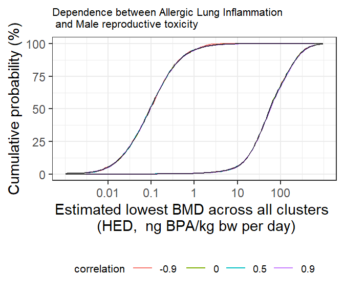

```r
df_dep <- get_dep(clid_deps=c(1,16),rhos = c(-0.9,0,0.5,0.9))
df_dep$correlation = as.character(df_dep$rho)

ggplot(data=df_dep,aes(x=dose,y=100*lower_cdf,color = correlation)) +
  geom_line()+
  geom_line(aes(x=dose,y=100*upper_cdf,color = correlation))+
geom_line(data=df_env_all,aes(x=dose,y=100*lower_cdf),col="black",alpha=0.7)+
geom_line(data=df_env_all,aes(x=dose,y=100*upper_cdf),col="black",alpha=0.7)+
theme_bw() +
  theme(legend.position="bottom",legend.title = element_text(size=8),
      legend.text = element_text(size=7)) +
  theme(plot.title = element_text(size = 8)) +
  ggtitle("Dependence between Allergic Lung Inflammation \n and Male reproductive toxicity") +
  ylab("Cumulative probability (%)") +
  scale_x_continuous(name="Estimated lowest BMD across all clusters \n (HED,  ng BPA/kg bw per day)", breaks=breaks, labels=10^breaks,limits = limits)
```

Female and ALI

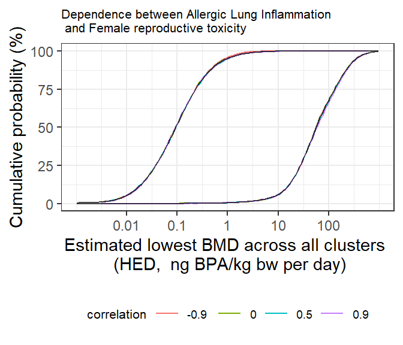

```r
df_dep <- get_dep(clid_deps=c(1,17),rhos = c(-0.9,0,0.5,0.9))
df_dep$correlation = as.character(df_dep$rho)

ggplot(data=df_dep,aes(x=dose,y=100*lower_cdf,color = correlation)) +
  geom_line()+
  geom_line(aes(x=dose,y=100*upper_cdf,color = correlation))+
geom_line(data=df_env_all,aes(x=dose,y=100*lower_cdf),col="black",alpha=0.7)+
geom_line(data=df_env_all,aes(x=dose,y=100*upper_cdf),col="black",alpha=0.7)+
theme_bw() +
  theme(legend.position="bottom",legend.title = element_text(size=8),
      legend.text = element_text(size=7)) +
  ggtitle("Dependence between Allergic Lung Inflammation \n and Female reproductive toxicity") +
  theme(plot.title = element_text(size = 8)) +
  ylab("Cumulative probability (%)") +
  scale_x_continuous(name="Estimated lowest BMD across all clusters \n (HED,  ng BPA/kg bw per day)", breaks=breaks, labels=10^breaks,limits = limits)
```

Male and CI

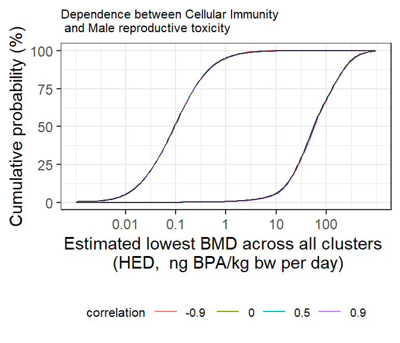

```r
df_dep <- get_dep(clid_deps=c(2,16),rhos = c(-0.9,0,0.5,0.9))
df_dep$correlation = as.character(df_dep$rho)

ggplot(data=df_dep,aes(x=dose,y=100*lower_cdf,color = correlation)) +
  geom_line()+
  geom_line(aes(x=dose,y=100*upper_cdf,color = correlation))+
geom_line(data=df_env_all,aes(x=dose,y=100*lower_cdf),col="black",alpha=0.7)+
geom_line(data=df_env_all,aes(x=dose,y=100*upper_cdf),col="black",alpha=0.7)+
theme_bw() +
  theme(legend.position="bottom",legend.title = element_text(size=8),
      legend.text = element_text(size=7)) +
  theme(plot.title = element_text(size = 8)) +
  ggtitle("Dependence between Cellular Immunity \n and Male reproductive toxicity") +
  ylab("Cumulative probability (%)") +
  scale_x_continuous(name="Estimated lowest BMD across all clusters \n (HED,  ng BPA/kg bw per day)", breaks=breaks, labels=10^breaks,limits = limits)
```

Female and CI

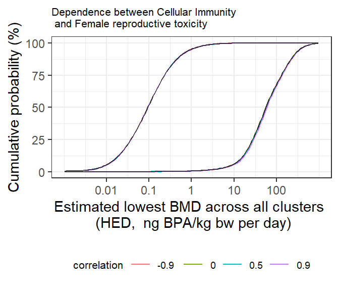

```r
df_dep <- get_dep(clid_deps=c(2,17),rhos = c(-0.9,0,0.5,0.9))
df_dep$correlation = as.character(df_dep$rho)

ggplot(data=df_dep,aes(x=dose,y=100*lower_cdf,color = correlation)) +
  geom_line()+
  geom_line(aes(x=dose,y=100*upper_cdf,color = correlation))+
geom_line(data=df_env_all,aes(x=dose,y=100*lower_cdf),col="black",alpha=0.7)+
geom_line(data=df_env_all,aes(x=dose,y=100*upper_cdf),col="black",alpha=0.7)+
theme_bw() +
  theme(legend.position="bottom",legend.title = element_text(size=8),
      legend.text = element_text(size=7)) +
  ggtitle("Dependence between Cellular Immunity \n and Female reproductive toxicity") +
  theme(plot.title = element_text(size = 8)) +
  ylab("Cumulative probability (%)") +
  scale_x_continuous(name="Estimated lowest BMD across all clusters \n (HED,  ng BPA/kg bw per day)", breaks=breaks, labels=10^breaks,limits = limits)
```

Male vs Female

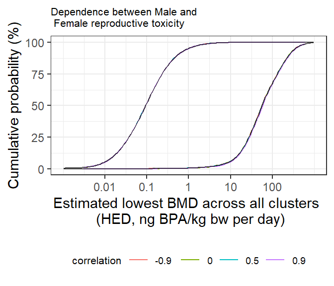

```r
df_dep <- get_dep(clid_deps=c(16,17),rhos = c(-0.9,0,0.5,0.9))
df_dep$correlation = as.character(df_dep$rho)

ggplot(data=df_dep,aes(x=dose,y=100*lower_cdf,color = correlation)) +
  geom_line()+
  geom_line(aes(x=dose,y=100*upper_cdf,color = correlation))+
geom_line(data=df_env_all,aes(x=dose,y=100*lower_cdf),col="black",alpha=0.7)+
geom_line(data=df_env_all,aes(x=dose,y=100*upper_cdf),col="black",alpha=0.7)+
theme_bw() +
 theme(legend.position="bottom",legend.title = element_text(size=8),
      legend.text = element_text(size=7)) +
   ggtitle("Dependence between Male and \n Female reproductive toxicity") +
theme(plot.title = element_text(size = 8)) +
  ylab("Cumulative probability (%)") +
  scale_x_continuous(name="Estimated lowest BMD across all clusters \n (HED, ng BPA/kg bw per day)", breaks=breaks, labels=10^breaks,limits = limits)
```

ALI vs CI

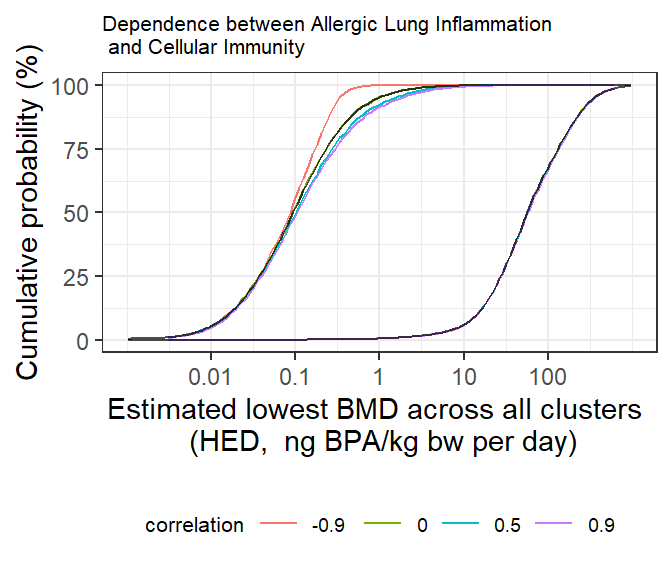

```r
df_dep <- get_dep(clid_deps=c(1,2),rhos = c(-0.9,0,0.5,0.9))
df_dep$correlation = as.character(df_dep$rho)

ggplot(data=df_dep,aes(x=dose,y=100*lower_cdf,color = correlation)) +
  geom_line()+
  geom_line(aes(x=dose,y=100*upper_cdf,color = correlation))+
geom_line(data=df_env_all,aes(x=dose,y=100*lower_cdf),col="black",alpha=0.7)+
geom_line(data=df_env_all,aes(x=dose,y=100*upper_cdf),col="black",alpha=0.7)+
theme_bw() +
  theme(legend.position="bottom",legend.title = element_text(size=8),
      legend.text = element_text(size=7)) +
  theme(plot.title = element_text(size = 8)) +
  ggtitle("Dependence between Allergic Lung Inflammation \n and Cellular Immunity") +
  ylab("Cumulative probability (%)") +
  scale_x_continuous(name="Estimated lowest BMD across all clusters \n (HED,  ng BPA/kg bw per day)", breaks=breaks, labels=10^breaks,limits = limits)
```